# MrOS_subcat

# Purpose

Examining Obstructive and Irritative categories (sub-catagories of LUTS) with respect to the urinary microbiome. Also adding the new diabetes categories (08/01/23 from MrOS_SAS_glucose.RMD)

**Samples** 500 morning, second voided urine specimens that were collected in sterile containers and frozen as part of the MrOS study were obtained with associated clinical information. Bacterial DNA was extracted and the 16S rRNA amplicon was sequenced with Illumina MiSeq. Sequences were processed with DADA2 and analyzed in R. LUTS severity was classified with American Urologic Association Symptom Index ( 0 -7 none/mild; 8-35 moderate/severe)

# Set-up

```r
library(phyloseq)
library(ggplot2)
library(tidyverse)
library(patchwork)
library(kableExtra)
library(RColorBrewer)
library(speedyseq)
library(here)
library(microshades)
library(qwraps2)
library(reshape2)
library(tableone)
library(vegan)
library(cowplot)
```

### Data origin

This ps object was cleaned up in Box/Kate/MrOS/data/Analyses/MrOS_EDA.Rmd. ALl of the data is described explicitly in that RMD. The ps object is *rarefied*

```r
load(here("data", "Final_Analyses", "ps_subcat.RData"))
```

# LUTS-Subanalysis

### LUTS categories -

According to AUA (american urology assoc), scores for each symptom go from 0 –> 5; 0 = never, 5 = almost always

1. Over the past month, how often have you had the feeling of not completely emptying your bladder after you finished urinating? *PSEMPTY*
2. Over the past month, how often have you had to urinate again less than 2 hours after you finished urinating? *PSAGAIN*
3. Over the past month, how often have you found that you stopped and started again several times when you urinated? *PSSTOP*
4. Over the past month, how often have you found it hard to hold your urine? *PSPOST*
5. Over the past month, how often have you had a weak urine stream? *PSWEAK*
6. Over the past month, how often have you had to push or strain to begin urination? *PSPUSH*
7. Over the past month, have you had to get up to urinate during the night? Give a score to the number of times. *PSUP*

# Contribution plots

```r
ps_g <- tax_glom(ps, "Genus")
ps_g <- subset_taxa(ps_g, taxa_sums(ps_g) > 0)



ps_p <- tax_glom(ps, "Phylum")
ps_p <- subset_taxa(ps_p, taxa_sums(ps_p) > 0)

ps_p_n  <- transform_sample_counts(ps_p, function(x) 100* x/sum(x))
# melt to a data frame
mdf <- ps_p_n %>%
          psmelt()
```

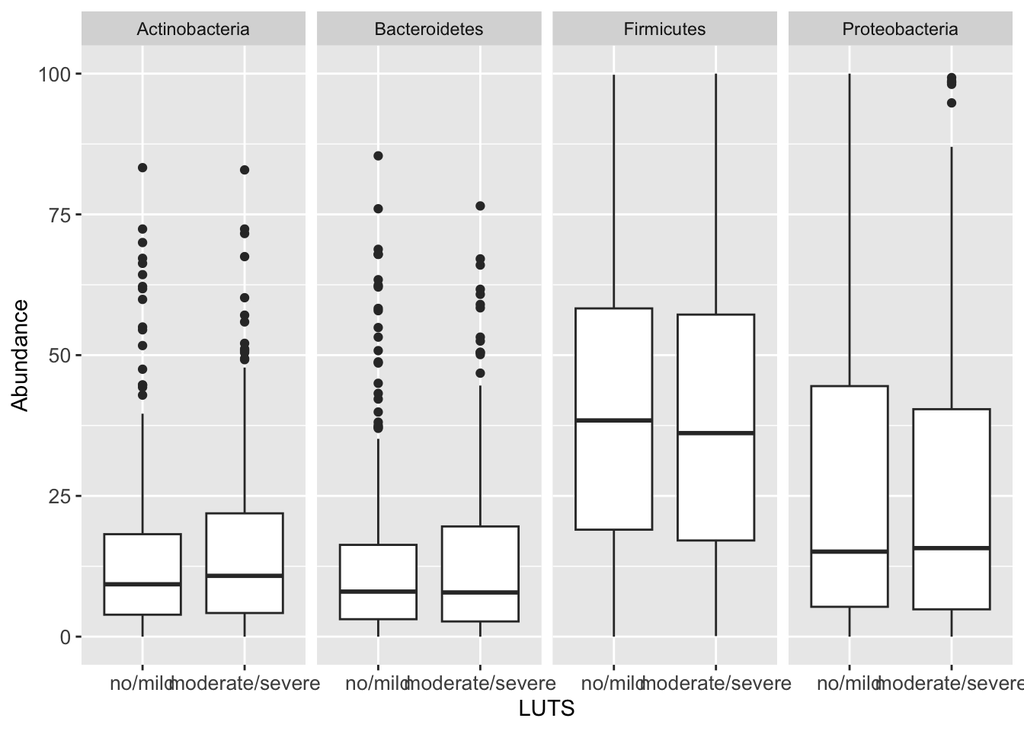

```r
mdf %>%
  filter(Phylum %in% c("Firmicutes", "Proteobacteria", "Actinobacteria", "Bacteroidetes")) %>%
  ggplot(., aes(x = LUTS_cat, y = Abundance)) +
  facet_wrap(~Phylum, nrow = 1) +
  geom_boxplot() +
  xlab("LUTS") +
  theme(axis.text.x = element_text(size = 10)) +
  theme(axis.text.y = element_text(size=10))
```

```r
color_dfs <- create_color_dfs(mdf, group_level = "Phylum")
color_dfs <- reorder_samples_by(color_dfs$mdf,color_dfs$cdf, order_tax = "Firmicutes")

# fix mdf
color_dfs$mdf$group <- str_replace(color_dfs$mdf$group, "-Unknown", "")

color_dfs$mdf$group <- factor(color_dfs$mdf$group, levels = c("Other", "Bacteroidetes", "Actinobacteria", "Proteobacteria", "Firmicutes"))

# fix cdf
color_dfs$cdf$group <- str_replace(color_dfs$cdf$group, "-Unknown", "")
color_dfs$cdf$group <- factor(color_dfs$cdf$group, levels = c("Other", "Bacteroidetes", "Actinobacteria", "Proteobacteria", "Firmicutes"))


plot_g <- plot_microshades(color_dfs$mdf,color_dfs$cdf, group_label = "Phylum")

phy_plot <- plot_g + facet_grid(~LUTS_cat, scales = "free_x") + theme(strip.background = element_rect(colour="black", fill="white"), axis.text.x = element_blank())
```

[figure not shown]

```r
mild_contribution <- plot_contributions(color_dfs$mdf,color_dfs$cdf, "LUTS_cat", "no/mild")
mod_contribution <- plot_contributions(color_dfs$mdf,color_dfs$cdf, "LUTS_cat", "moderate/severe")
mild_contribution$median +
  mod_contribution$median + theme(axis.title.y=element_blank(), axis.text.y= element_blank(), axis.ticks.y=element_blank())
```

### Obstructive and Irritative distribution

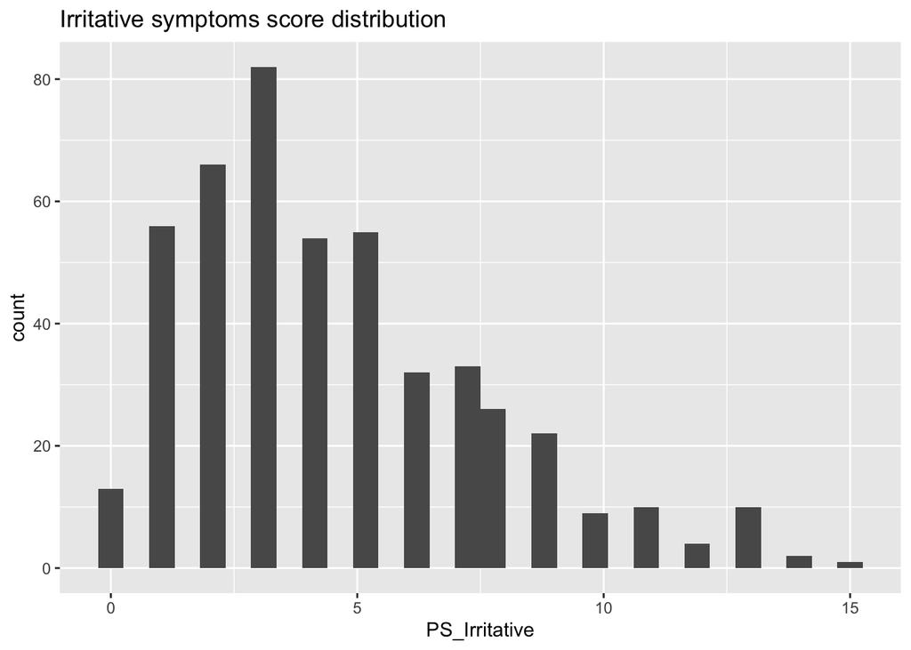

```r
ggplot(meta_ps, aes(x = PS_Irritative)) + geom_histogram() + ggtitle("Irritative symptoms score distribution")
```

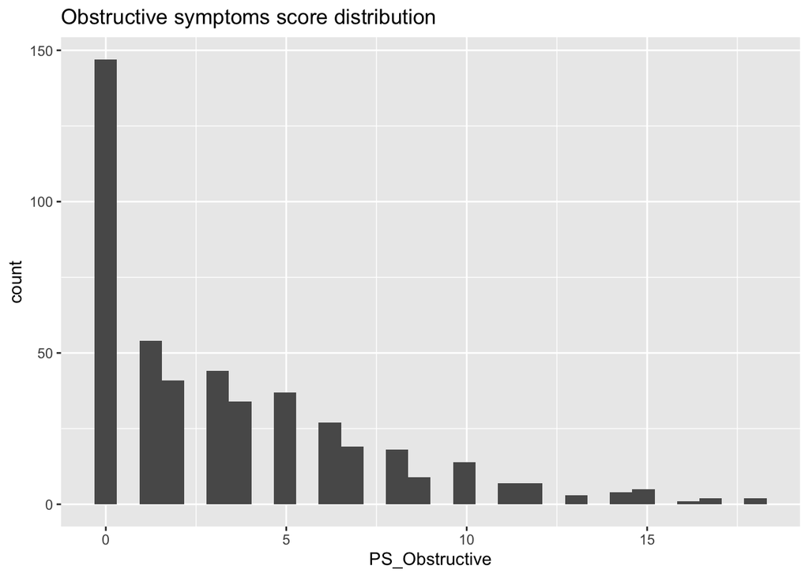

```r
ggplot(meta_ps, aes(x = PS_Obstructive)) + geom_histogram() + ggtitle("Obstructive symptoms score distribution")
```

```r
median(meta_ps$PS_Irritative)
```

```
## [1] 4
```

```r
median(meta_ps$PS_Obstructive)
```

```
## [1] 2
```

Hypothesis: microbiome is associated with irritative symptoms but not with obstructive

### histogram comparing the two

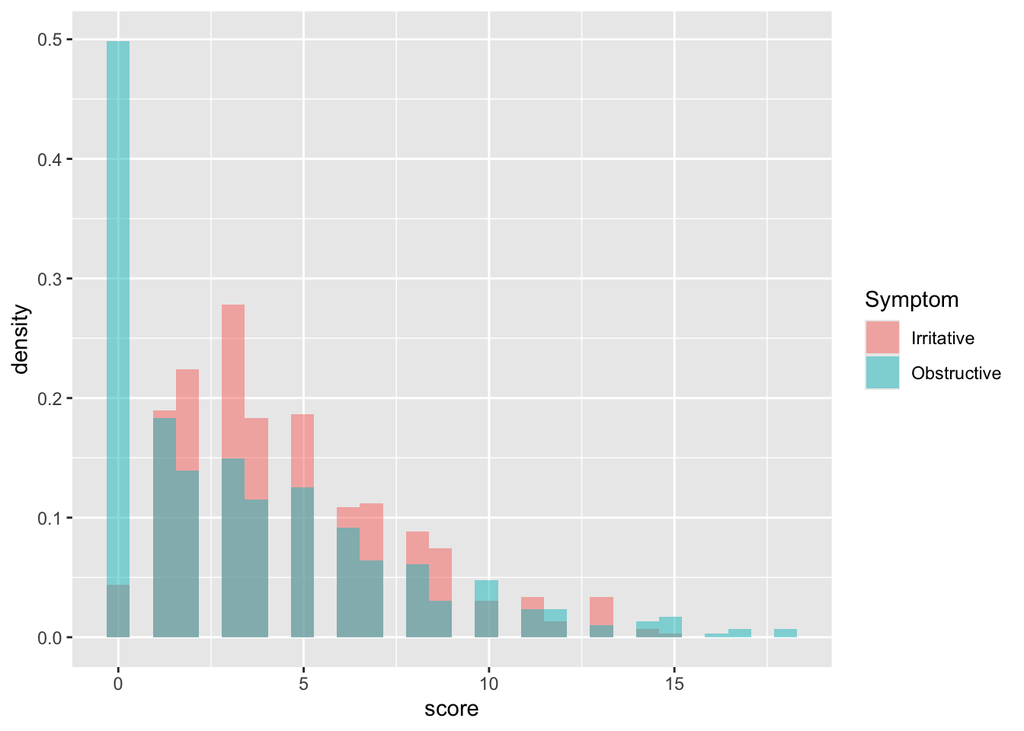

```r
test_obs <- data.frame(meta_ps$PS_Obstructive)
test_obs['score'] <- data.frame(meta_ps$PS_Obstructive)
test_obs$Symptom <- "Obstructive"
test_obs <- test_obs %>% select(score, Symptom)

test_irr <- data.frame(meta_ps$PS_Irritative)
test_irr['score'] <- data.frame(meta_ps$PS_Irritative)
test_irr$Symptom <- "Irritative"
test_irr <- test_irr %>% select(score, Symptom)

test_hist <- rbind(test_obs, test_irr)

ggplot(test_hist, aes(score, fill = Symptom)) + geom_histogram(alpha = 0.5, aes(y = ..density..), position = 'identity')
```

```r
# removing extraneous objects
rm(test_hist, test_irr, test_obs)
```

### plotting all samples

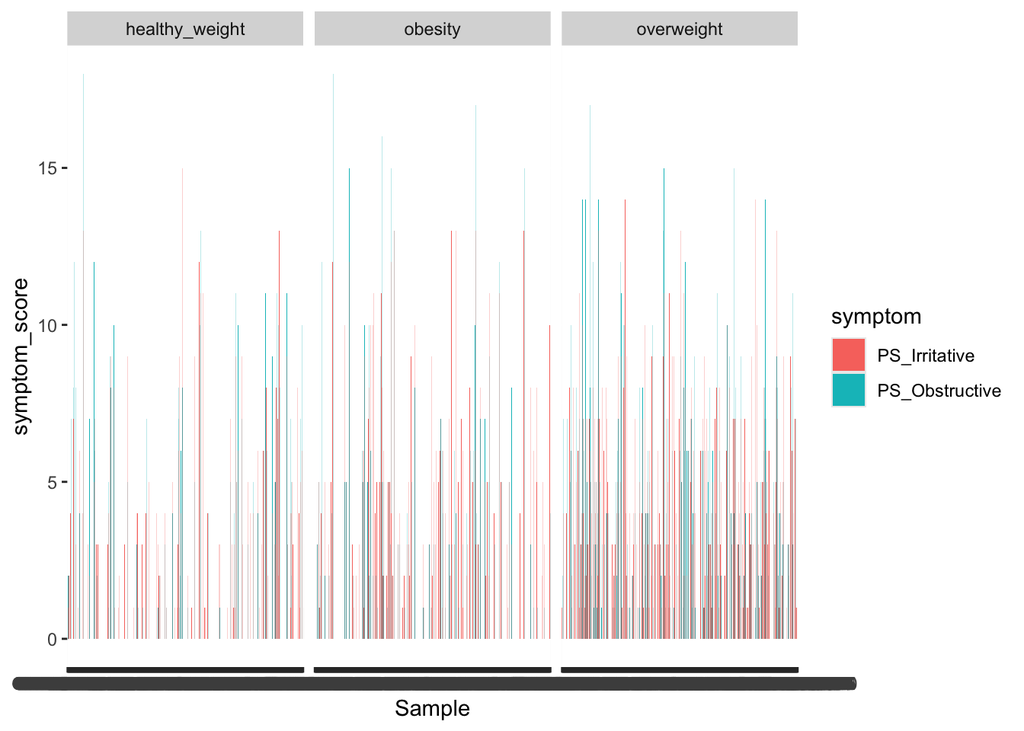

```r
meta_ps %>%
  pivot_longer(., cols = c("PS_Obstructive", "PS_Irritative"), names_to = "symptom", values_to = "symptom_score") %>%
  ggplot(., aes(x = Sample, y = symptom_score, fill = symptom)) + geom_bar(stat = "identity", position = position_dodge()) + facet_wrap(~BMI_group)
```

# Alpha div

### Obstructive

#### Correlation test

```r
# Testing normality
shapiro.test(meta_ps$PS_Obstructive)
```

```
##
##  Shapiro-Wilk normality test
##
## data:  meta_ps$PS_Obstructive
## W = 0.84133, p-value < 2.2e-16
```

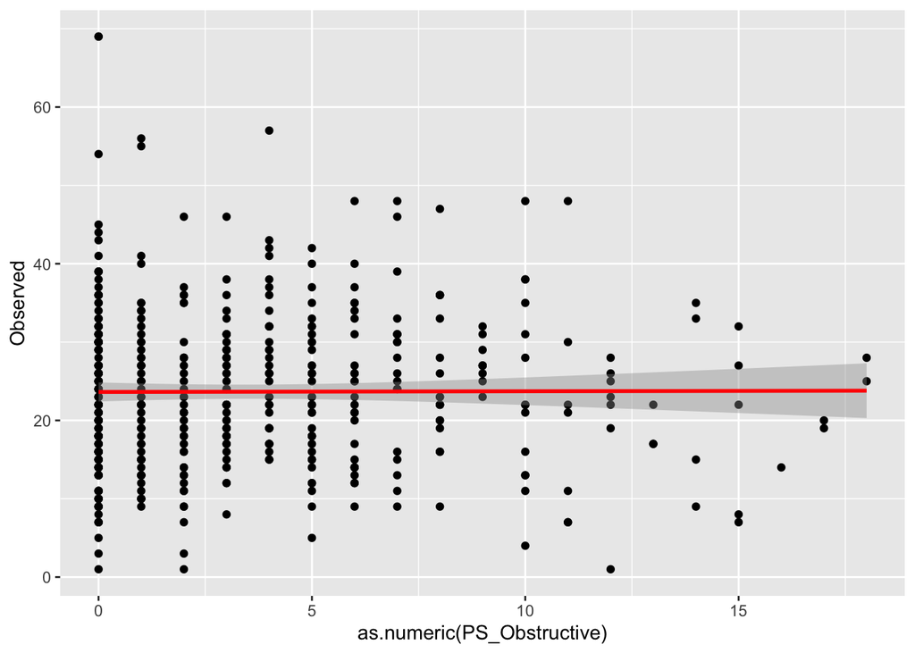

```r
# testing Observed
ggplot(meta_ps, aes(x = as.numeric(PS_Obstructive), y = Observed)) + geom_point() + stat_smooth(method = "lm", col = "red")
```

```r
res <- cor.test(as.numeric(meta_ps$PS_Obstructive), meta_ps$Observed,
                    method = "spearman") #pearson is for normal, spearman is for non-normal
res$p.value
```

```
## [1] 0.3120031
```

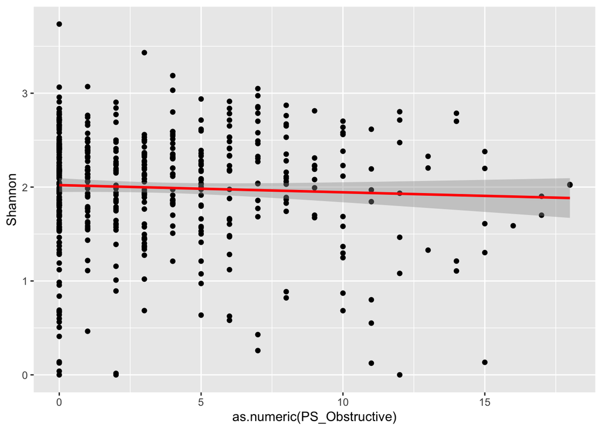

```r
# testing Shannon
ggplot(meta_ps, aes(x = as.numeric(PS_Obstructive), y = Shannon)) + geom_point() + stat_smooth(method = "lm", col = "red")
```

```r
res <- cor.test(as.numeric(meta_ps$PS_Obstructive), meta_ps$Shannon,
                    method = "spearman") #pearson is for normal, spearman is for non-normal
res$p.value
```

```
## [1] 0.9457776
```

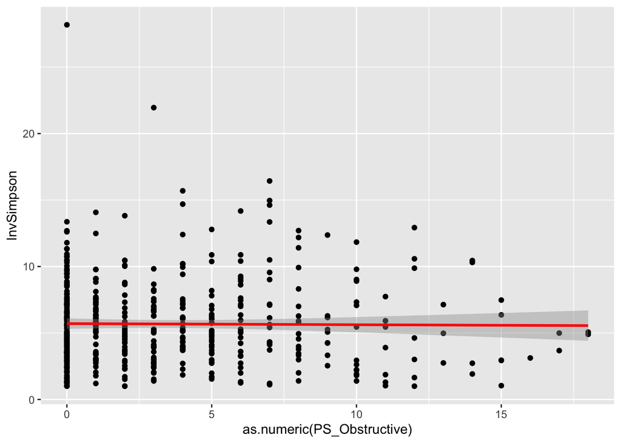

```r
# testing InvSimpson
ggplot(meta_ps, aes(x = as.numeric(PS_Obstructive), y = InvSimpson)) + geom_point() +
  stat_smooth(method = "lm", col = "red")
```

```r
res <- cor.test(as.numeric(meta_ps$PS_Obstructive), meta_ps$InvSimpson,
                    method = "spearman") #pearson is for normal, spearman is for non-normal
res$p.value
```

```
## [1] 0.9777382
```

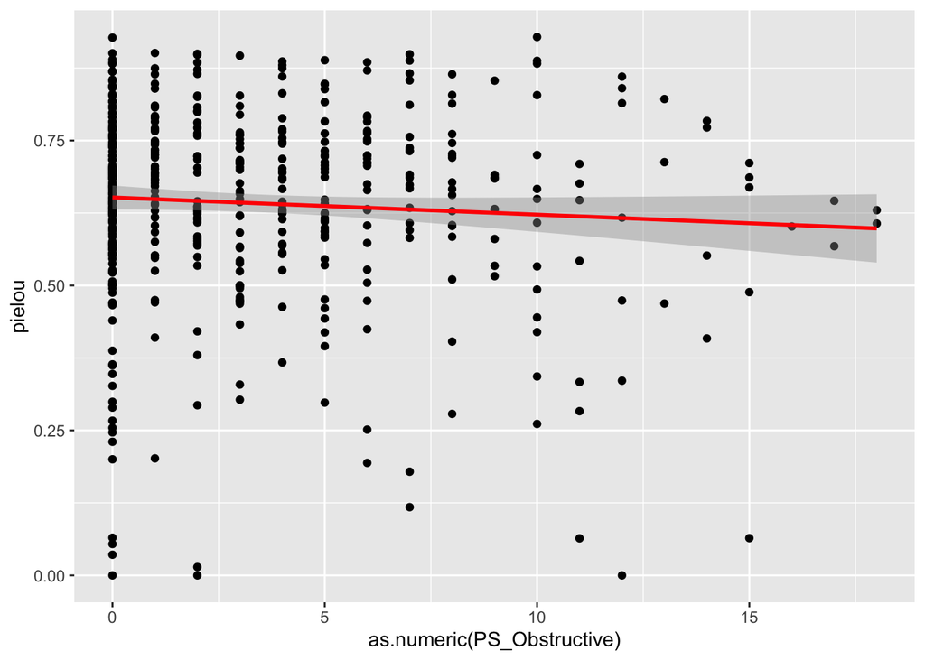

```r
# Testing pielou
ggplot(meta_ps, aes(x = as.numeric(PS_Obstructive), y = pielou)) + geom_point() + stat_smooth(method = "lm", col = "red")
```

```r
res <- cor.test(as.numeric(meta_ps$PS_Obstructive), meta_ps$pielou,
                    method = "spearman") #pearson is for normal, spearman is for non-normal
res$p.value
```

```
## [1] 0.4937532
```

```r
# test PS_Obstructive, all alpha div measures for normality firsts
```

alpha div NOT significantly associated with Obstructive symptoms

### Irritative

```r
shapiro.test(meta_ps$PS_Irritative)
```

```
##
##  Shapiro-Wilk normality test
##
## data:  meta_ps$PS_Irritative
## W = 0.92447, p-value = 1.023e-14
```

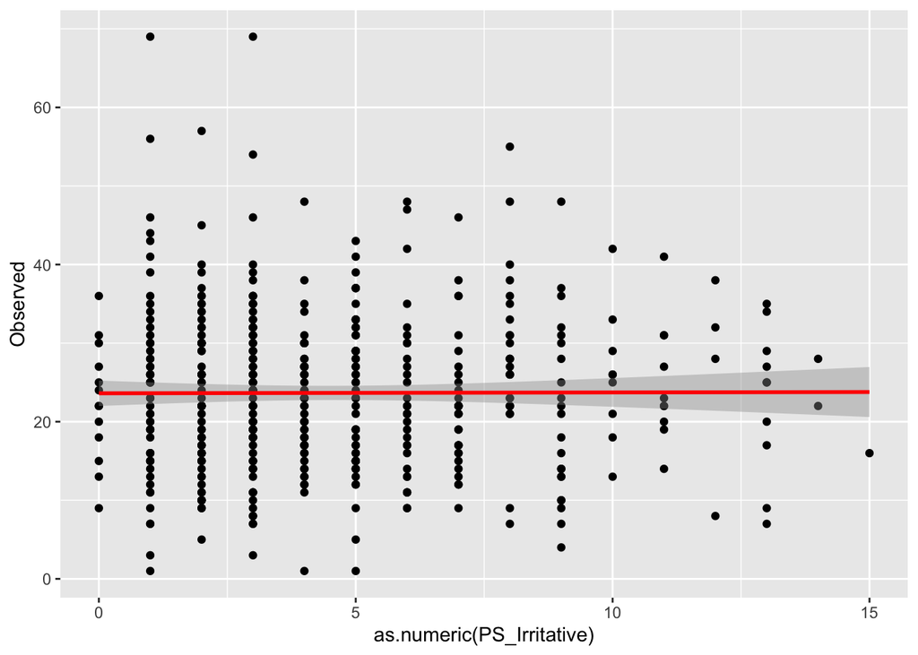

```r
# testing Observed
ggplot(meta_ps, aes(x = as.numeric(PS_Irritative), y = Observed)) + geom_point() + stat_smooth(method = "lm", col = "red")
```

```r
res <- cor.test(as.numeric(meta_ps$PS_Irritative), meta_ps$Observed,
                    method = "spearman") #pearson is for normal, spearman is for non-normal
res$p.value
```

```
## [1] 0.7982456
```

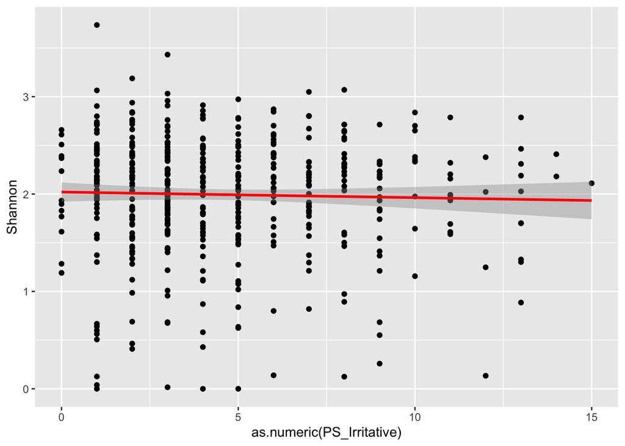

```r
# testing Shannon
ggplot(meta_ps, aes(x = as.numeric(PS_Irritative), y = Shannon)) + geom_point() + stat_smooth(method = "lm", col = "red")
```

```r
res <- cor.test(as.numeric(meta_ps$PS_Irritative), meta_ps$Shannon,
                    method = "spearman") #pearson is for normal, spearman is for non-normal
res$p.value
```

```
## [1] 0.4168378
```

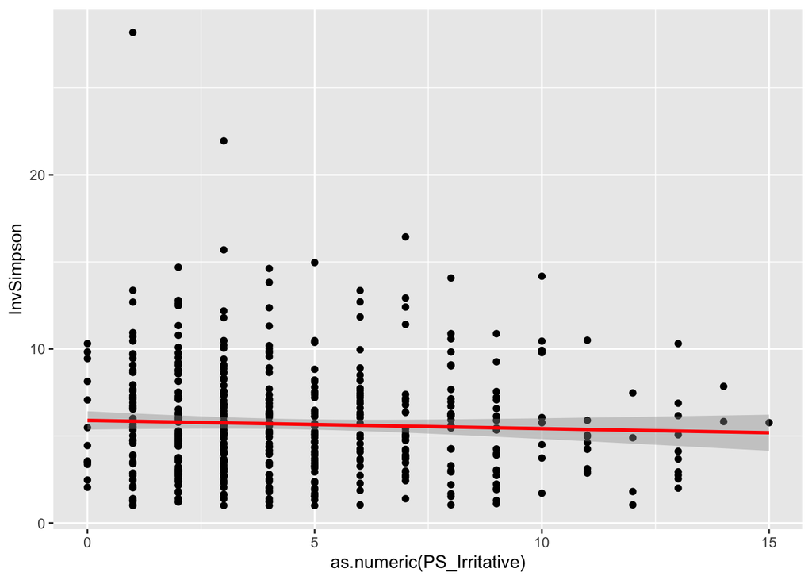

```r
# testing InvSimpson
ggplot(meta_ps, aes(x = as.numeric(PS_Irritative), y = InvSimpson)) + geom_point() +
  stat_smooth(method = "lm", col = "red")
```

```r
res <- cor.test(as.numeric(meta_ps$PS_Irritative), meta_ps$InvSimpson,
                    method = "spearman") #pearson is for normal, spearman is for non-normal
res$p.value
```

```
## [1] 0.6029085
```

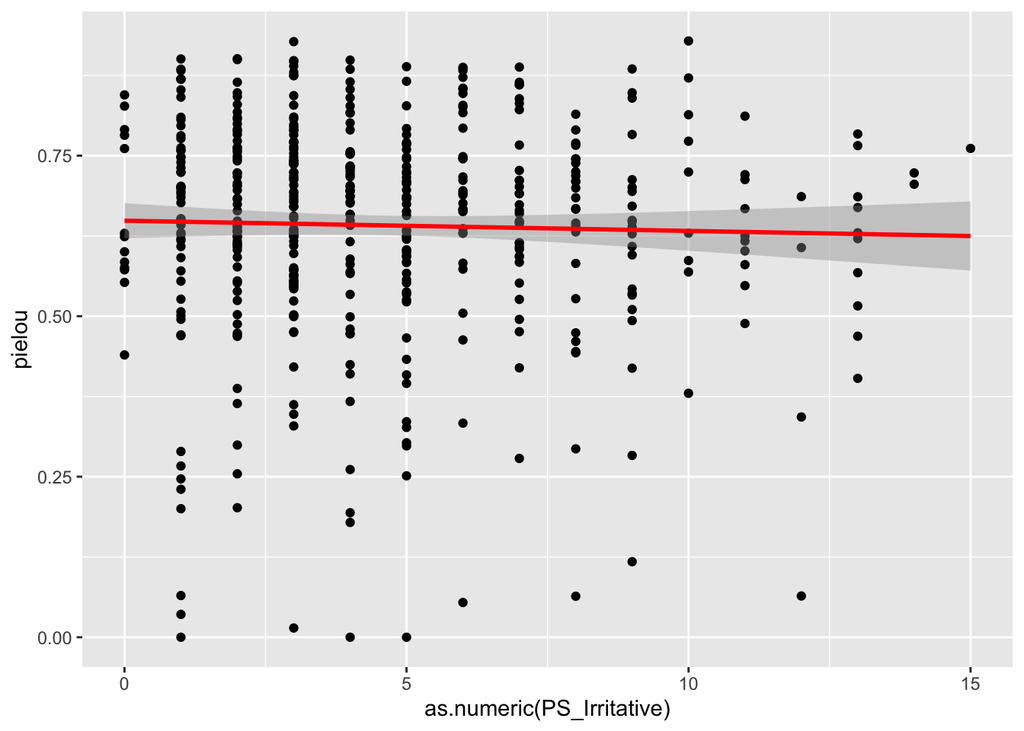

```r
# Testing pielou
ggplot(meta_ps, aes(x = as.numeric(PS_Irritative), y = pielou)) + geom_point() + stat_smooth(method = "lm", col = "red")
```

```r
res <- cor.test(as.numeric(meta_ps$PS_Irritative), meta_ps$pielou,
                    method = "spearman") #pearson is for normal, spearman is for non-normal
res$p.value
```

```
## [1] 0.3987606
```

```r
# test PS_Irritative, all alpha div measures for normality firsts
```

# Alpha Diversity - interactions

### Obstructive

#### Linear model (regression)

```r
obs.model <- lm(Observed ~ PS_Obstructive * BPH * BMI_group + age, data = meta_ps)
summary(obs.model)
```

```
##
## Call:
## lm(formula = Observed ~ PS_Obstructive * BPH * BMI_group + age,
##     data = meta_ps)
##
## Residuals:
##     Min      1Q  Median      3Q     Max
## -23.140  -7.035  -0.649   5.913  45.545
##
## Coefficients:
##                                           Estimate Std. Error t value Pr(>|t|)
## (Intercept)                               25.35273    6.38902   3.968 8.39e-05
## PS_Obstructive                             0.22017    0.37016   0.595    0.552
## BPHYes                                     1.48849    2.74384   0.542    0.588
## BMI_groupobesity                           0.09677    2.31576   0.042    0.967
## BMI_groupoverweight                       -0.23674    2.08843  -0.113    0.910
## age                                       -0.02373    0.08402  -0.282    0.778
## PS_Obstructive:BPHYes                     -0.42037    0.50837  -0.827    0.409
## PS_Obstructive:BMI_groupobesity           -0.45010    0.45980  -0.979    0.328
## PS_Obstructive:BMI_groupoverweight        -0.19466    0.50137  -0.388    0.698
## BPHYes:BMI_groupobesity                   -0.08416    3.74751  -0.022    0.982
## BPHYes:BMI_groupoverweight                -2.40472    3.27759  -0.734    0.464
## PS_Obstructive:BPHYes:BMI_groupobesity     0.70788    0.69534   1.018    0.309
## PS_Obstructive:BPHYes:BMI_groupoverweight  0.54814    0.64870   0.845    0.399
##
## (Intercept)                               ***
## PS_Obstructive
## BPHYes
## BMI_groupobesity
## BMI_groupoverweight
## age
## PS_Obstructive:BPHYes
## PS_Obstructive:BMI_groupobesity
## PS_Obstructive:BMI_groupoverweight
## BPHYes:BMI_groupobesity
## BPHYes:BMI_groupoverweight
## PS_Obstructive:BPHYes:BMI_groupobesity
## PS_Obstructive:BPHYes:BMI_groupoverweight
## ---
## Signif. codes:  0 '***' 0.001 '**' 0.01 '*' 0.05 '.' 0.1 ' ' 1
##
## Residual standard error: 10.12 on 462 degrees of freedom
## Multiple R-squared:  0.009396,   Adjusted R-squared:  -0.01633
## F-statistic: 0.3652 on 12 and 462 DF,  p-value: 0.9749
```

```r
shan.model <- lm(Shannon ~ PS_Obstructive * BPH * BMI_group + age, data = meta_ps)
summary(shan.model)
```

```
##
## Call:
## lm(formula = Shannon ~ PS_Obstructive * BPH * BMI_group + age,
##     data = meta_ps)
##
## Residuals:
##     Min      1Q  Median      3Q     Max
## -2.0509 -0.2837  0.1034  0.3662  1.6665
##
## Coefficients:
##                                            Estimate Std. Error t value Pr(>|t|)
## (Intercept)                                2.196630   0.379840   5.783 1.35e-08
## PS_Obstructive                             0.038398   0.022007   1.745  0.08168
## BPHYes                                     0.275200   0.163127   1.687  0.09227
## BMI_groupobesity                          -0.082632   0.137677  -0.600  0.54868
## BMI_groupoverweight                        0.155766   0.124162   1.255  0.21028
## age                                       -0.004036   0.004995  -0.808  0.41944
## PS_Obstructive:BPHYes                     -0.084415   0.030224  -2.793  0.00544
## PS_Obstructive:BMI_groupobesity           -0.043314   0.027336  -1.585  0.11376
## PS_Obstructive:BMI_groupoverweight        -0.060488   0.029807  -2.029  0.04300
## BPHYes:BMI_groupobesity                    0.064639   0.222797   0.290  0.77185
## BPHYes:BMI_groupoverweight                -0.260346   0.194859  -1.336  0.18218
## PS_Obstructive:BPHYes:BMI_groupobesity     0.085404   0.041340   2.066  0.03939
## PS_Obstructive:BPHYes:BMI_groupoverweight  0.098592   0.038567   2.556  0.01089
##
## (Intercept)                               ***
## PS_Obstructive                            .
## BPHYes                                    .
## BMI_groupobesity
## BMI_groupoverweight
## age
## PS_Obstructive:BPHYes                     **
## PS_Obstructive:BMI_groupobesity
## PS_Obstructive:BMI_groupoverweight        *
## BPHYes:BMI_groupobesity
## BPHYes:BMI_groupoverweight
## PS_Obstructive:BPHYes:BMI_groupobesity    *
## PS_Obstructive:BPHYes:BMI_groupoverweight *
## ---
## Signif. codes:  0 '***' 0.001 '**' 0.01 '*' 0.05 '.' 0.1 ' ' 1
##
## Residual standard error: 0.6014 on 462 degrees of freedom
## Multiple R-squared:  0.04518,    Adjusted R-squared:  0.02038
## F-statistic: 1.822 on 12 and 462 DF,  p-value: 0.04239
```

```r
invsimp.model <- lm(InvSimpson ~ PS_Obstructive * BPH * BMI_group + age, data = meta_ps)
summary(invsimp.model)
```

```
##
## Call:
## lm(formula = InvSimpson ~ PS_Obstructive * BPH * BMI_group +
##     age, data = meta_ps)
##
## Residuals:
##     Min      1Q  Median      3Q     Max
## -5.3387 -2.2792 -0.4578  1.4273 21.9067
##
## Coefficients:
##                                           Estimate Std. Error t value Pr(>|t|)
## (Intercept)                                6.07489    2.05067   2.962  0.00321
## PS_Obstructive                             0.28772    0.11881   2.422  0.01583
## BPHYes                                     1.10430    0.88068   1.254  0.21051
## BMI_groupobesity                          -0.13154    0.74329  -0.177  0.85961
## BMI_groupoverweight                        1.28484    0.67032   1.917  0.05589
## age                                       -0.01553    0.02697  -0.576  0.56507
## PS_Obstructive:BPHYes                     -0.44281    0.16317  -2.714  0.00690
## PS_Obstructive:BMI_groupobesity           -0.28824    0.14758  -1.953  0.05141
## PS_Obstructive:BMI_groupoverweight        -0.46055    0.16092  -2.862  0.00440
## BPHYes:BMI_groupobesity                    0.18568    1.20283   0.154  0.87738
## BPHYes:BMI_groupoverweight                -1.40795    1.05200  -1.338  0.18144
## PS_Obstructive:BPHYes:BMI_groupobesity     0.48318    0.22318   2.165  0.03090
## PS_Obstructive:BPHYes:BMI_groupoverweight  0.61465    0.20821   2.952  0.00332
##
## (Intercept)                               **
## PS_Obstructive                            *
## BPHYes
## BMI_groupobesity
## BMI_groupoverweight                       .
## age
## PS_Obstructive:BPHYes                     **
## PS_Obstructive:BMI_groupobesity           .
## PS_Obstructive:BMI_groupoverweight        **
## BPHYes:BMI_groupobesity
## BPHYes:BMI_groupoverweight
## PS_Obstructive:BPHYes:BMI_groupobesity    *
## PS_Obstructive:BPHYes:BMI_groupoverweight **
## ---
## Signif. codes:  0 '***' 0.001 '**' 0.01 '*' 0.05 '.' 0.1 ' ' 1
##
## Residual standard error: 3.247 on 462 degrees of freedom
## Multiple R-squared:  0.04026,    Adjusted R-squared:  0.01533
## F-statistic: 1.615 on 12 and 462 DF,  p-value: 0.08411
```

```r
pie.model<- lm(pielou ~ PS_Obstructive * BPH * BMI_group + age, data = meta_ps)
summary(pie.model)
```

```
##
## Call:
## lm(formula = pielou ~ PS_Obstructive * BPH * BMI_group + age,
##     data = meta_ps)
##
## Residuals:
##      Min       1Q   Median       3Q      Max
## -0.63973 -0.07034  0.02653  0.11002  0.33228
##
## Coefficients:
##                                            Estimate Std. Error t value Pr(>|t|)
## (Intercept)                                0.721151   0.105315   6.848  2.4e-11
## PS_Obstructive                             0.009895   0.006102   1.622  0.10554
## BPHYes                                     0.083613   0.045229   1.849  0.06515
## BMI_groupobesity                          -0.034925   0.038173  -0.915  0.36071
## BMI_groupoverweight                        0.049865   0.034425   1.448  0.14816
## age                                       -0.001472   0.001385  -1.063  0.28848
## PS_Obstructive:BPHYes                     -0.024313   0.008380  -2.901  0.00389
## PS_Obstructive:BMI_groupobesity           -0.009681   0.007579  -1.277  0.20213
## PS_Obstructive:BMI_groupoverweight        -0.017380   0.008264  -2.103  0.03601
## BPHYes:BMI_groupobesity                    0.011766   0.061773   0.190  0.84902
## BPHYes:BMI_groupoverweight                -0.059972   0.054027  -1.110  0.26756
## PS_Obstructive:BPHYes:BMI_groupobesity     0.024211   0.011462   2.112  0.03519
## PS_Obstructive:BPHYes:BMI_groupoverweight  0.026468   0.010693   2.475  0.01367
##
## (Intercept)                               ***
## PS_Obstructive
## BPHYes                                    .
## BMI_groupobesity
## BMI_groupoverweight
## age
## PS_Obstructive:BPHYes                     **
## PS_Obstructive:BMI_groupobesity
## PS_Obstructive:BMI_groupoverweight        *
## BPHYes:BMI_groupobesity
## BPHYes:BMI_groupoverweight
## PS_Obstructive:BPHYes:BMI_groupobesity    *
## PS_Obstructive:BPHYes:BMI_groupoverweight *
## ---
## Signif. codes:  0 '***' 0.001 '**' 0.01 '*' 0.05 '.' 0.1 ' ' 1
##
## Residual standard error: 0.1667 on 462 degrees of freedom
## Multiple R-squared:  0.05853,    Adjusted R-squared:  0.03408
## F-statistic: 2.394 on 12 and 462 DF,  p-value: 0.005234
```

```r
meta_ps$BMI_group_f <- factor(meta_ps$BMI_group, levels = c("healthy_weight", "overweight", "obesity"))
```

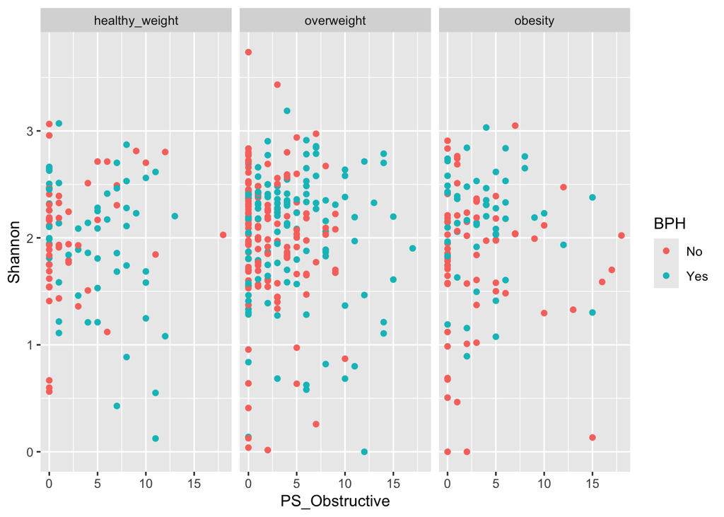

```r
meta_ps %>%
  ggplot(., aes(x = PS_Obstructive, y = Shannon, colour = BPH)) + geom_point() + facet_wrap(~BMI_group_f)
```

### Irritative

```r
obs.model <- lm(Observed ~ PS_Irritative * BPH * BMI_group + age, data = meta_ps)
summary(obs.model)
```

```
##
## Call:
## lm(formula = Observed ~ PS_Irritative * BPH * BMI_group + age,
##     data = meta_ps)
##
## Residuals:
##     Min      1Q  Median      3Q     Max
## -21.983  -7.028  -0.608   5.585  46.386
##
## Coefficients:
##                                          Estimate Std. Error t value Pr(>|t|)
## (Intercept)                              23.71627    6.59527   3.596 0.000358
## PS_Irritative                             0.58035    0.50806   1.142 0.253928
## BPHYes                                    2.66401    3.48815   0.764 0.445418
## BMI_groupobesity                          0.14392    3.19612   0.045 0.964102
## BMI_groupoverweight                       2.28092    2.87035   0.795 0.427225
## age                                      -0.02288    0.08429  -0.271 0.786128
## PS_Irritative:BPHYes                     -0.68754    0.66296  -1.037 0.300243
## PS_Irritative:BMI_groupobesity           -0.42357    0.63088  -0.671 0.502305
## PS_Irritative:BMI_groupoverweight        -0.81281    0.62293  -1.305 0.192606
## BPHYes:BMI_groupobesity                   3.07608    4.83444   0.636 0.524906
## BPHYes:BMI_groupoverweight               -4.83357    4.22744  -1.143 0.253474
## PS_Irritative:BPHYes:BMI_groupobesity     0.04132    0.86195   0.048 0.961787
## PS_Irritative:BPHYes:BMI_groupoverweight  1.11728    0.80928   1.381 0.168073
##
## (Intercept)                              ***
## PS_Irritative
## BPHYes
## BMI_groupobesity
## BMI_groupoverweight
## age
## PS_Irritative:BPHYes
## PS_Irritative:BMI_groupobesity
## PS_Irritative:BMI_groupoverweight
## BPHYes:BMI_groupobesity
## BPHYes:BMI_groupoverweight
## PS_Irritative:BPHYes:BMI_groupobesity
## PS_Irritative:BPHYes:BMI_groupoverweight
## ---
## Signif. codes:  0 '***' 0.001 '**' 0.01 '*' 0.05 '.' 0.1 ' ' 1
##
## Residual standard error: 10.09 on 462 degrees of freedom
## Multiple R-squared:  0.01362,    Adjusted R-squared:  -0.012
## F-statistic: 0.5315 on 12 and 462 DF,  p-value: 0.8944
```

```r
shan.model <- lm(Shannon ~ PS_Irritative * BPH * BMI_group + age, data = meta_ps)
summary(shan.model)
```

```
##
## Call:
## lm(formula = Shannon ~ PS_Irritative * BPH * BMI_group + age,
##     data = meta_ps)
##
## Residuals:
##     Min      1Q  Median      3Q     Max
## -2.0511 -0.2921  0.0939  0.3930  1.6658
##
## Coefficients:
##                                           Estimate Std. Error t value Pr(>|t|)
## (Intercept)                               2.080007   0.393057   5.292 1.87e-07
## PS_Irritative                             0.056194   0.030279   1.856   0.0641
## BPHYes                                    0.397933   0.207883   1.914   0.0562
## BMI_groupobesity                          0.021238   0.190478   0.112   0.9113
## BMI_groupoverweight                       0.284464   0.171063   1.663   0.0970
## age                                      -0.003935   0.005023  -0.783   0.4338
## PS_Irritative:BPHYes                     -0.101155   0.039510  -2.560   0.0108
## PS_Irritative:BMI_groupobesity           -0.058604   0.037598  -1.559   0.1198
## PS_Irritative:BMI_groupoverweight        -0.074641   0.037125  -2.011   0.0450
## BPHYes:BMI_groupobesity                   0.099153   0.288117   0.344   0.7309
## BPHYes:BMI_groupoverweight               -0.493151   0.251942  -1.957   0.0509
## PS_Irritative:BPHYes:BMI_groupobesity     0.072095   0.051370   1.403   0.1612
## PS_Irritative:BPHYes:BMI_groupoverweight  0.130189   0.048230   2.699   0.0072
##
## (Intercept)                              ***
## PS_Irritative                            .
## BPHYes                                   .
## BMI_groupobesity
## BMI_groupoverweight                      .
## age
## PS_Irritative:BPHYes                     *
## PS_Irritative:BMI_groupobesity
## PS_Irritative:BMI_groupoverweight        *
## BPHYes:BMI_groupobesity
## BPHYes:BMI_groupoverweight               .
## PS_Irritative:BPHYes:BMI_groupobesity
## PS_Irritative:BPHYes:BMI_groupoverweight **
## ---
## Signif. codes:  0 '***' 0.001 '**' 0.01 '*' 0.05 '.' 0.1 ' ' 1
##
## Residual standard error: 0.6015 on 462 degrees of freedom
## Multiple R-squared:  0.04462,    Adjusted R-squared:  0.0198
## F-statistic: 1.798 on 12 and 462 DF,  p-value: 0.04598
```

```r
invsimp.model <- lm(InvSimpson ~ PS_Irritative * BPH * BMI_group + age, data = meta_ps)
summary(invsimp.model)
```

```
##
## Call:
## lm(formula = InvSimpson ~ PS_Irritative * BPH * BMI_group + age,
##     data = meta_ps)
##
## Residuals:
##     Min      1Q  Median      3Q     Max
## -5.6157 -2.1736 -0.4903  1.5123 21.6178
##
## Coefficients:
##                                          Estimate Std. Error t value Pr(>|t|)
## (Intercept)                               5.41320    2.11809   2.556  0.01092
## PS_Irritative                             0.33148    0.16317   2.032  0.04277
## BPHYes                                    1.74556    1.12023   1.558  0.11987
## BMI_groupobesity                          0.69400    1.02644   0.676  0.49930
## BMI_groupoverweight                       2.31634    0.92182   2.513  0.01232
## age                                      -0.01316    0.02707  -0.486  0.62711
## PS_Irritative:BPHYes                     -0.50481    0.21291  -2.371  0.01815
## PS_Irritative:BMI_groupobesity           -0.40280    0.20261  -1.988  0.04739
## PS_Irritative:BMI_groupoverweight        -0.57804    0.20006  -2.889  0.00404
## BPHYes:BMI_groupobesity                  -0.03913    1.55259  -0.025  0.97990
## BPHYes:BMI_groupoverweight               -2.94331    1.35765  -2.168  0.03067
## PS_Irritative:BPHYes:BMI_groupobesity     0.46252    0.27682   1.671  0.09543
## PS_Irritative:BPHYes:BMI_groupoverweight  0.81890    0.25990   3.151  0.00173
##
## (Intercept)                              *
## PS_Irritative                            *
## BPHYes
## BMI_groupobesity
## BMI_groupoverweight                      *
## age
## PS_Irritative:BPHYes                     *
## PS_Irritative:BMI_groupobesity           *
## PS_Irritative:BMI_groupoverweight        **
## BPHYes:BMI_groupobesity
## BPHYes:BMI_groupoverweight               *
## PS_Irritative:BPHYes:BMI_groupobesity    .
## PS_Irritative:BPHYes:BMI_groupoverweight **
## ---
## Signif. codes:  0 '***' 0.001 '**' 0.01 '*' 0.05 '.' 0.1 ' ' 1
##
## Residual standard error: 3.242 on 462 degrees of freedom
## Multiple R-squared:  0.04325,    Adjusted R-squared:  0.0184
## F-statistic:  1.74 on 12 and 462 DF,  p-value: 0.05583
```

```r
pie.model<- lm(pielou ~ PS_Irritative * BPH * BMI_group + age, data = meta_ps)
summary(pie.model)
```

```
##
## Call:
## lm(formula = pielou ~ PS_Irritative * BPH * BMI_group + age,
##     data = meta_ps)
##
## Residuals:
##      Min       1Q   Median       3Q      Max
## -0.65220 -0.07265  0.03003  0.10608  0.32674
##
## Coefficients:
##                                           Estimate Std. Error t value Pr(>|t|)
## (Intercept)                               0.692945   0.109570   6.324 6.01e-10
## PS_Irritative                             0.014997   0.008441   1.777   0.0763
## BPHYes                                    0.114307   0.057950   1.973   0.0491
## BMI_groupobesity                          0.005992   0.053098   0.113   0.9102
## BMI_groupoverweight                       0.074062   0.047686   1.553   0.1211
## age                                      -0.001497   0.001400  -1.069   0.2856
## PS_Irritative:BPHYes                     -0.028356   0.011014  -2.575   0.0103
## PS_Irritative:BMI_groupobesity           -0.017140   0.010481  -1.635   0.1027
## PS_Irritative:BMI_groupoverweight        -0.017986   0.010349  -1.738   0.0829
## BPHYes:BMI_groupobesity                  -0.005869   0.080316  -0.073   0.9418
## BPHYes:BMI_groupoverweight               -0.114418   0.070232  -1.629   0.1040
## PS_Irritative:BPHYes:BMI_groupobesity     0.026058   0.014320   1.820   0.0695
## PS_Irritative:BPHYes:BMI_groupoverweight  0.032358   0.013445   2.407   0.0165
##
## (Intercept)                              ***
## PS_Irritative                            .
## BPHYes                                   *
## BMI_groupobesity
## BMI_groupoverweight
## age
## PS_Irritative:BPHYes                     *
## PS_Irritative:BMI_groupobesity
## PS_Irritative:BMI_groupoverweight        .
## BPHYes:BMI_groupobesity
## BPHYes:BMI_groupoverweight
## PS_Irritative:BPHYes:BMI_groupobesity    .
## PS_Irritative:BPHYes:BMI_groupoverweight *
## ---
## Signif. codes:  0 '***' 0.001 '**' 0.01 '*' 0.05 '.' 0.1 ' ' 1
##
## Residual standard error: 0.1677 on 462 degrees of freedom
## Multiple R-squared:  0.04775,    Adjusted R-squared:  0.02301
## F-statistic:  1.93 on 12 and 462 DF,  p-value: 0.02906
```

# trends and overall LUTS

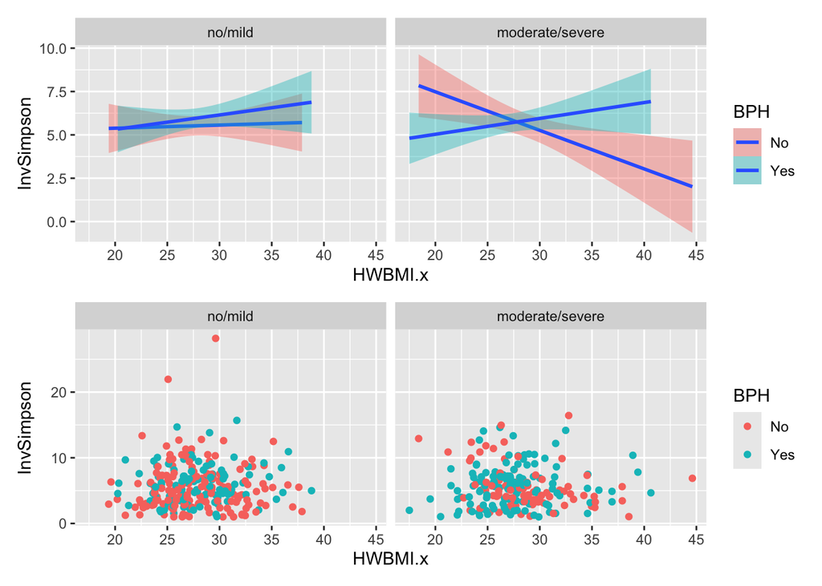

```r
LUTS_line <- meta_ps %>%
  ggplot(., aes(x = HWBMI.x, y = InvSimpson, fill = BPH)) +
  geom_smooth(method = "lm") + facet_wrap(~LUTS_cat)

LUTS_pt <- meta_ps %>%
  ggplot(., aes(x = HWBMI.x, y = InvSimpson, colour = BPH)) +
  geom_point() + facet_wrap(~LUTS_cat)

LUTS_line / LUTS_pt
```

# BPH/BMI Obstructive/Irritative trends

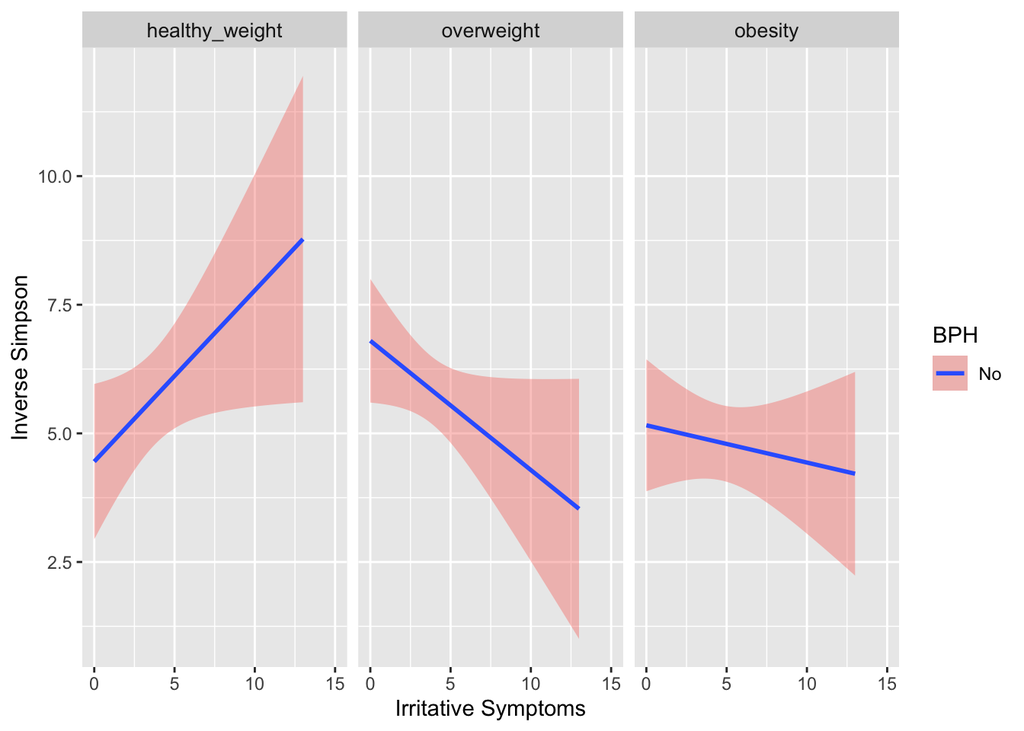

```r
#meta_ps %>%
 # ggplot(., aes(x = factor(PS_Irritative), y = InvSimpson, fill = BPH)) +
 # geom_boxplot() + facet_wrap(~BMI_group)

BMI_labs <- c("healthy weight", "overweight", "obese")
names(BMI_labs) <- c("healthy_weight", "overweight", "obese")

meta_ps %>%
  filter(BPH == "No") %>%
  ggplot(., aes(x = PS_Irritative, y = InvSimpson, fill = BPH)) +
  geom_smooth(method = "lm") +
  facet_wrap(~BMI_group_f) +
  xlab("Irritative Symptoms") +
  ylab("Inverse Simpson") +
  theme(strip.text = element_text(size=10)) +
  scale_x_continuous(limits = c(0, 15))
```

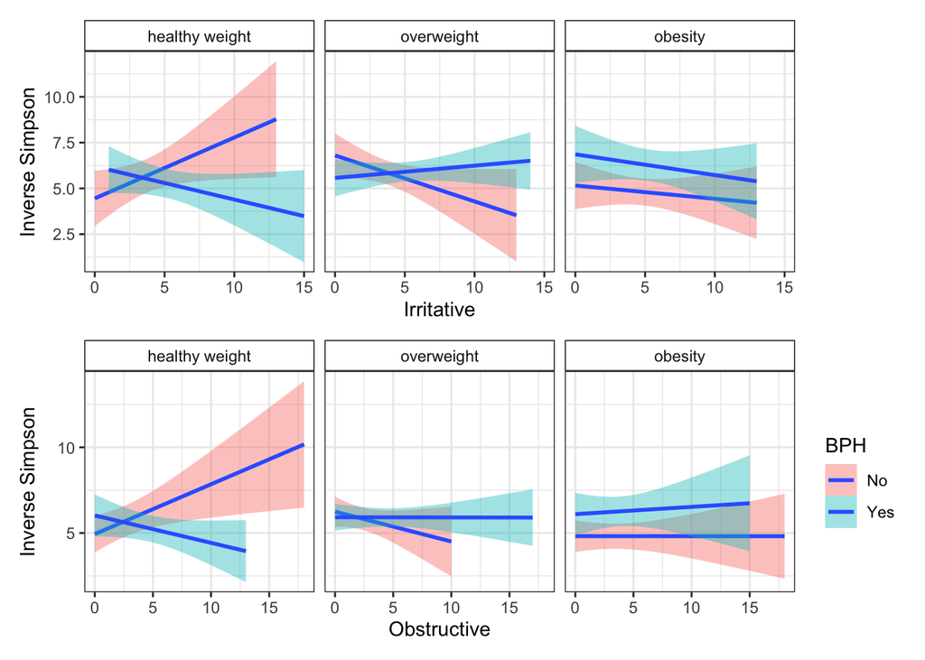

```r
Obs_line <- meta_ps %>%
  ggplot(., aes(x = PS_Obstructive, y = InvSimpson, fill = BPH)) +
  geom_smooth(method = "lm") +
  theme_bw() +
  theme(strip.background = element_rect(colour="black", fill="white")) +
  facet_wrap(~BMI_group_f, labeller=labeller(BMI_group_f=as_labeller(BMI_labs))) + xlab("Obstructive") + ylab("Inverse Simpson")

Obs_pt <- meta_ps %>%
  ggplot(., aes(x = PS_Obstructive, y = InvSimpson, colour = BPH)) +
  geom_point() + facet_wrap(~BMI_group)



Irr_line <- meta_ps %>%
  ggplot(., aes(x = PS_Irritative, y = InvSimpson, fill = BPH)) +
  geom_smooth(method = "lm") +
  theme_bw() +
  facet_wrap(~BMI_group_f, labeller=labeller(BMI_group_f=as_labeller(BMI_labs))) + theme(legend.position = "none", strip.background = element_rect(colour="black", fill="white")) +
  xlab("Irritative") + ylab("Inverse Simpson")

Irr_pt <- meta_ps %>%
  ggplot(., aes(x = PS_Irritative, y = InvSimpson, colour = BPH)) +
  geom_point() + facet_wrap(~BMI_group)

Irr_line / Obs_line
```

# supplemental figure

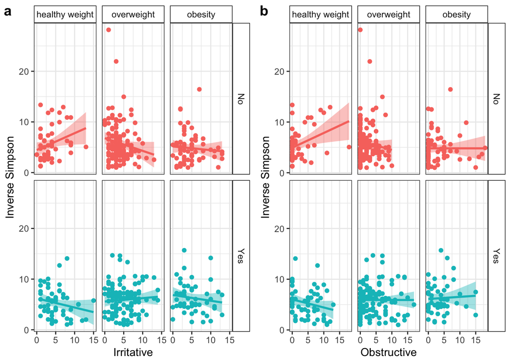

```r
Obs_supp <- meta_ps %>%
  ggplot(., aes(x = PS_Obstructive, y = InvSimpson, fill = BPH, colour = BPH)) +
  geom_smooth(method = "lm") +
  theme_bw() +
  geom_point() +
  theme(strip.background = element_rect(colour="black", fill="white")) +
  facet_grid(BPH~BMI_group_f, labeller=labeller(BMI_group_f=as_labeller(BMI_labs))) + xlab("Obstructive") +
  ylab("Inverse Simpson") +
  theme(legend.position = "none")



Irr_supp <- meta_ps %>%
  ggplot(., aes(x = PS_Irritative, y = InvSimpson, fill = BPH, colour = BPH)) +
  geom_smooth(method = "lm") +
  theme_bw() +
  geom_point() +
  facet_grid(BPH~BMI_group_f, labeller=labeller(BMI_group_f=as_labeller(BMI_labs))) + theme(legend.position = "none", strip.background = element_rect(colour="black", fill="white")) +
  xlab("Irritative") + ylab("Inverse Simpson")


plot_grid(Irr_supp, Obs_supp, labels = c("a", "b"))
```

```r
table(meta_ps$BMI_group, meta_ps$BPH)
```

```
##
##                   No Yes
##   healthy_weight  49  55
##   obesity         67  51
##   overweight     131 122
```

# Adonis

```r
dist_wu_ps <- phyloseq::distance(ps_g, method = "wunifrac")
dist_u_ps <- phyloseq::distance(ps_g, method = "unifrac")
dist_b_ps <- phyloseq::distance(ps_g, method = "bray")
```

### weighted unifrac

```r
adonis2(dist_wu_ps~ age + BPH * BMI_group * PS_Obstructive, data = meta_ps)
```

|  | Df | SumOfSqs | R2 | F | Pr(>F) |
| --- | --- | --- | --- | --- | --- |
| Model | 12 | 1.522926 | 0.0297722 | 1.181402 | 0.093 |
| Residual | 462 | 49.629708 | 0.9702278 | NA | NA |
| Total | 474 | 51.152634 | 1.0000000 | NA | NA |

```r
adonis2(dist_wu_ps~ age + BPH * BMI_group * PS_Irritative, data = meta_ps)
```

|  | Df | SumOfSqs | R2 | F | Pr(>F) |
| --- | --- | --- | --- | --- | --- |
| Model | 12 | 1.567881 | 0.030651 | 1.217379 | 0.066 |
| Residual | 462 | 49.584753 | 0.969349 | NA | NA |
| Total | 474 | 51.152634 | 1.000000 | NA | NA |

#### un-adjusted model

```r
adonis2(dist_wu_ps~ PS_Obstructive, data = meta_ps)
```

|  | Df | SumOfSqs | R2 | F | Pr(>F) |
| --- | --- | --- | --- | --- | --- |
| Model | 1 | 0.0923675 | 0.0018057 | 0.855652 | 0.559 |
| Residual | 473 | 51.0602664 | 0.9981943 | NA | NA |
| Total | 474 | 51.1526339 | 1.0000000 | NA | NA |

```r
adonis2(dist_wu_ps~ PS_Irritative, data = meta_ps)
```

|  | Df | SumOfSqs | R2 | F | Pr(>F) |
| --- | --- | --- | --- | --- | --- |
| Model | 1 | 0.1268773 | 0.0024804 | 1.17613 | 0.294 |
| Residual | 473 | 51.0257566 | 0.9975196 | NA | NA |
| Total | 474 | 51.1526339 | 1.0000000 | NA | NA |

### unweighted unifrac

```r
adonis2(dist_u_ps~ age + BPH * BMI_group * PS_Obstructive, data = meta_ps)
```

|  | Df | SumOfSqs | R2 | F | Pr(>F) |
| --- | --- | --- | --- | --- | --- |
| Model | 12 | 2.821987 | 0.0297629 | 1.18102 | 0.027 |
| Residual | 462 | 91.993766 | 0.9702371 | NA | NA |
| Total | 474 | 94.815753 | 1.0000000 | NA | NA |

```r
adonis2(dist_u_ps~ age + BPH * BMI_group * PS_Irritative, data = meta_ps)
```

|  | Df | SumOfSqs | R2 | F | Pr(>F) |
| --- | --- | --- | --- | --- | --- |
| Model | 12 | 2.851568 | 0.0300748 | 1.193784 | 0.021 |
| Residual | 462 | 91.964185 | 0.9699252 | NA | NA |
| Total | 474 | 94.815753 | 1.0000000 | NA | NA |

#### unadjusted model

```r
adonis2(dist_u_ps~ PS_Obstructive, data = meta_ps)
```

|  | Df | SumOfSqs | R2 | F | Pr(>F) |
| --- | --- | --- | --- | --- | --- |
| Model | 1 | 0.2311454 | 0.0024378 | 1.155915 | 0.275 |
| Residual | 473 | 94.5846075 | 0.9975622 | NA | NA |
| Total | 474 | 94.8157528 | 1.0000000 | NA | NA |

```r
adonis2(dist_u_ps~ PS_Irritative, data = meta_ps)
```

|  | Df | SumOfSqs | R2 | F | Pr(>F) |
| --- | --- | --- | --- | --- | --- |
| Model | 1 | 0.2190699 | 0.0023105 | 1.095388 | 0.283 |
| Residual | 473 | 94.5966829 | 0.9976895 | NA | NA |
| Total | 474 | 94.8157528 | 1.0000000 | NA | NA |

### BrayCurtis

```r
#adonis2(dist_b_ps~ LUTS_cat * HWBMI.x * age, data = meta_ps)

adonis2(dist_b_ps~ PS_Obstructive + BPH * HWBMI.x + age, data = meta_ps)
```

|  | Df | SumOfSqs | R2 | F | Pr(>F) |
| --- | --- | --- | --- | --- | --- |
| Model | 5 | 3.445461 | 0.0202679 | 1.940458 | 0.001 |
| Residual | 469 | 166.550503 | 0.9797321 | NA | NA |
| Total | 474 | 169.995965 | 1.0000000 | NA | NA |

```r
adonis2(dist_b_ps~ PS_Irritative + BPH * HWBMI.x + age, data = meta_ps)
```

|  | Df | SumOfSqs | R2 | F | Pr(>F) |
| --- | --- | --- | --- | --- | --- |
| Model | 5 | 3.449716 | 0.0202929 | 1.942904 | 0.001 |
| Residual | 469 | 166.546248 | 0.9797071 | NA | NA |
| Total | 474 | 169.995965 | 1.0000000 | NA | NA |

#### unadjusted model

```r
adonis2(dist_b_ps~ PS_Obstructive, data = meta_ps)
```

|  | Df | SumOfSqs | R2 | F | Pr(>F) |
| --- | --- | --- | --- | --- | --- |
| Model | 1 | 0.3229981 | 0.0019 | 0.9004269 | 0.559 |
| Residual | 473 | 169.6729664 | 0.9981 | NA | NA |
| Total | 474 | 169.9959645 | 1.0000 | NA | NA |

```r
adonis2(dist_b_ps~ PS_Irritative, data = meta_ps)
```

|  | Df | SumOfSqs | R2 | F | Pr(>F) |
| --- | --- | --- | --- | --- | --- |
| Model | 1 | 0.398119 | 0.0023419 | 1.110334 | 0.295 |
| Residual | 473 | 169.597846 | 0.9976581 | NA | NA |
| Total | 474 | 169.995965 | 1.0000000 | NA | NA |

# Obs vs Irr vs Both (sub_LUTS)

```r
meta_ps <- meta_ps %>%
  mutate(sub_LUTS = case_when(
    PS_Obstructive > 0 & PS_Irritative == 0 ~ "Obstructive",
    PS_Irritative > 0 & PS_Obstructive == 0 ~ "Irritative",
    PS_Irritative > 0 & PS_Obstructive > 0 ~ "Both",
    PS_Irritative == 0 & PS_Obstructive == 0 ~ "None"
))


temp <- as.data.frame(table(meta_ps$sub_LUTS))
temp <- temp %>% mutate(count = (Freq/sum(Freq)*100))
temp$Symptom <- temp$Var1
temp$Symptom <- factor(temp$Symptom, levels = c("None", "Obstructive", "Irritative", "Both"))

pchart <- ggplot(temp, aes(x = "", y = count, fill = Symptom)) + geom_bar(stat = "identity")
pchart_fin <- pchart + coord_polar("y", start=0) + scale_fill_manual(values = c("#8E4D63","#E3C565","#90AFC5", "#b4d3b2")) + theme_void()

sample_data(ps) <- meta_ps
```

# Figure 4

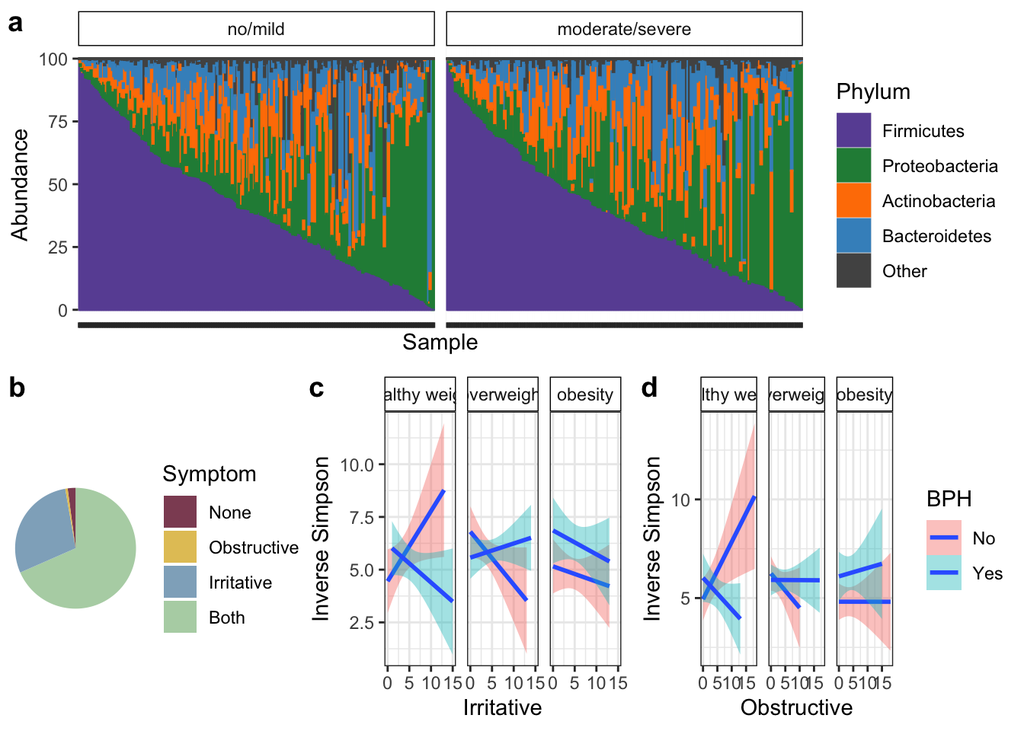

```r
bottom_row <- plot_grid(pchart_fin, Irr_line, Obs_line, labels = c("b", "c", "d"), rel_widths = c(1, 1.1, 1.3), nrow = 1)
plot_grid(phy_plot, bottom_row, labels = c("a", ""), nrow = 2)
```

### Alpha diversity - sub_LUTS

```r
kruskal.test(meta_ps$Observed ~ meta_ps$sub_LUTS)
```

```
##
##  Kruskal-Wallis rank sum test
##
## data:  meta_ps$Observed by meta_ps$sub_LUTS
## Kruskal-Wallis chi-squared = 0.38877, df = 3, p-value = 0.9426
```

```r
kruskal.test(meta_ps$InvSimpson ~ meta_ps$sub_LUTS)
```

```
##
##  Kruskal-Wallis rank sum test
##
## data:  meta_ps$InvSimpson by meta_ps$sub_LUTS
## Kruskal-Wallis chi-squared = 1.6879, df = 3, p-value = 0.6396
```

```r
kruskal.test(meta_ps$Shannon ~ meta_ps$sub_LUTS)
```

```
##
##  Kruskal-Wallis rank sum test
##
## data:  meta_ps$Shannon by meta_ps$sub_LUTS
## Kruskal-Wallis chi-squared = 1.1841, df = 3, p-value = 0.7568
```

```r
kruskal.test(meta_ps$pielou ~ meta_ps$sub_LUTS)
```

```
##
##  Kruskal-Wallis rank sum test
##
## data:  meta_ps$pielou by meta_ps$sub_LUTS
## Kruskal-Wallis chi-squared = 1.6202, df = 3, p-value = 0.6548
```

### Adonis - sub_LUTS

```r
adonis2(dist_wu_ps~ sub_LUTS, data = meta_ps)
```

|  | Df | SumOfSqs | R2 | F | Pr(>F) |
| --- | --- | --- | --- | --- | --- |
| Model | 3 | 0.2883414 | 0.0056369 | 0.8900074 | 0.602 |
| Residual | 471 | 50.8642925 | 0.9943631 | NA | NA |
| Total | 474 | 51.1526339 | 1.0000000 | NA | NA |

```r
adonis2(dist_u_ps~ sub_LUTS, data = meta_ps)
```

|  | Df | SumOfSqs | R2 | F | Pr(>F) |
| --- | --- | --- | --- | --- | --- |
| Model | 3 | 0.5664922 | 0.0059747 | 0.9436602 | 0.593 |
| Residual | 471 | 94.2492606 | 0.9940253 | NA | NA |
| Total | 474 | 94.8157528 | 1.0000000 | NA | NA |

```r
adonis2(dist_b_ps~ sub_LUTS, data = meta_ps)
```

|  | Df | SumOfSqs | R2 | F | Pr(>F) |
| --- | --- | --- | --- | --- | --- |
| Model | 3 | 0.9895445 | 0.005821 | 0.9192461 | 0.617 |
| Residual | 471 | 169.0064200 | 0.994179 | NA | NA |
| Total | 474 | 169.9959645 | 1.000000 | NA | NA |

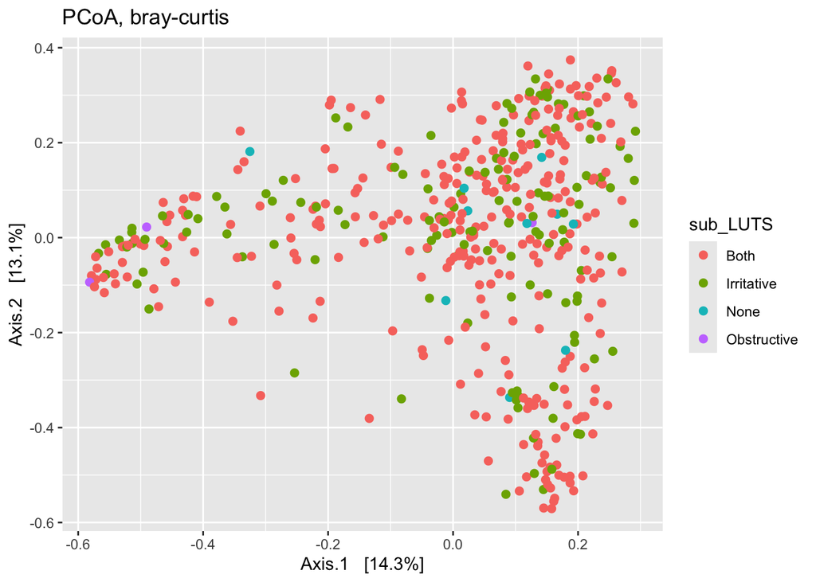

```r
# adding ordination plot
ps_ord <- ordinate(ps, method = "PCoA", distance = "bray")


ord_plot <- plot_ordination(ps, ps_ord,  color = "sub_LUTS", axes = c(1, 2)) +
    geom_point(size = 2) + ggtitle(paste("PCoA, bray-curtis"))

plot(ord_plot)
```

# Separating Obstructive/Irritative into categories

```r
# creating groups
meta_ps$Irr_group <- 'mild'
meta_ps$Irr_group[meta_ps$PS_Irritative > 4] <- 'severe'

table(meta_ps$Irr_group)
```

```
##
##   mild severe
##    271    204
```

```r
# creating groups
meta_ps$Obs_group <- 'mild'
meta_ps$Obs_group[meta_ps$PS_Obstructive > 4] <- 'severe'

table(meta_ps$Obs_group)
```

```
##
##   mild severe
##    320    155
```

```r
sample_data(ps) <- meta_ps
```

# Looking at top Phylum

```r
ps_n <- transform_sample_counts(ps,function(x) 100* x/sum(x))
ps_n_phy <- tax_glom(ps_n, "Phylum")
ps_melt <- psmelt(ps_n_phy)
summary_phylum <- ps_melt %>%
        group_by(Phylum, Obs_group) %>%
        summarise(rank_abundance = sum(Abundance), mean_abundance = mean(Abundance), median_abundance = median(Abundance), min_abundance = min(Abundance), max_abundance = max(Abundance)) %>%
        arrange(desc(rank_abundance)) %>%
        mutate(order = row_number()) %>%
        ungroup()
# Firmicutes
ps_melt <- psmelt(ps_n_phy) %>% filter(Phylum == "Firmicutes")
kruskal.test(ps_melt$Abundance ~ ps_melt$Obs_group)
```

```
##
##  Kruskal-Wallis rank sum test
##
## data:  ps_melt$Abundance by ps_melt$Obs_group
## Kruskal-Wallis chi-squared = 0.62624, df = 1, p-value = 0.4287
```

```r
# Proteobacteria
ps_melt <- psmelt(ps_n_phy) %>% filter(Phylum == "Proteobacteria")
kruskal.test(ps_melt$Abundance ~ ps_melt$Obs_group)
```

```
##
##  Kruskal-Wallis rank sum test
##
## data:  ps_melt$Abundance by ps_melt$Obs_group
## Kruskal-Wallis chi-squared = 0.42601, df = 1, p-value = 0.514
```

```r
# Actinobacteria
ps_melt <- psmelt(ps_n_phy) %>% filter(Phylum == "Actinobacteria")
kruskal.test(ps_melt$Abundance ~ ps_melt$Obs_group)
```

```
##
##  Kruskal-Wallis rank sum test
##
## data:  ps_melt$Abundance by ps_melt$Obs_group
## Kruskal-Wallis chi-squared = 0.00081327, df = 1, p-value = 0.9772
```

```r
# Bacteroidetes
ps_melt <- psmelt(ps_n_phy) %>% filter(Phylum == "Bacteroidetes")
kruskal.test(ps_melt$Abundance ~ ps_melt$Obs_group)
```

```
##
##  Kruskal-Wallis rank sum test
##
## data:  ps_melt$Abundance by ps_melt$Obs_group
## Kruskal-Wallis chi-squared = 0.25308, df = 1, p-value = 0.6149
```

```r
# Fusobacteria
ps_melt <- psmelt(ps_n_phy) %>% filter(Phylum == "Fusobacteria")
kruskal.test(ps_melt$Abundance ~ ps_melt$Obs_group)
```

```
##
##  Kruskal-Wallis rank sum test
##
## data:  ps_melt$Abundance by ps_melt$Obs_group
## Kruskal-Wallis chi-squared = 0.87894, df = 1, p-value = 0.3485
```

## Irritative

```r
ps_melt <- psmelt(ps_n_phy)
summary_phylum <- ps_melt %>%
        group_by(Phylum, PS_Irritative) %>%
        summarise(rank_abundance = sum(Abundance), mean_abundance = mean(Abundance), median_abundance = median(Abundance), min_abundance = min(Abundance), max_abundance = max(Abundance)) %>%
        arrange(desc(rank_abundance)) %>%
        mutate(order = row_number()) %>%
        ungroup()
# Firmicutes
ps_melt <- psmelt(ps_n_phy) %>% filter(Phylum == "Firmicutes")
kruskal.test(ps_melt$Abundance ~ ps_melt$PS_Irritative)
```

```
##
##  Kruskal-Wallis rank sum test
##
## data:  ps_melt$Abundance by ps_melt$PS_Irritative
## Kruskal-Wallis chi-squared = 8.5427, df = 15, p-value = 0.9002
```

```r
# Proteobacteria
ps_melt <- psmelt(ps_n_phy) %>% filter(Phylum == "Proteobacteria")
kruskal.test(ps_melt$Abundance ~ ps_melt$PS_Irritative)
```

```
##
##  Kruskal-Wallis rank sum test
##
## data:  ps_melt$Abundance by ps_melt$PS_Irritative
## Kruskal-Wallis chi-squared = 12.735, df = 15, p-value = 0.6228
```

```r
# Actinobacteria
ps_melt <- psmelt(ps_n_phy) %>% filter(Phylum == "Actinobacteria")
kruskal.test(ps_melt$Abundance ~ ps_melt$PS_Irritative)
```

```
##
##  Kruskal-Wallis rank sum test
##
## data:  ps_melt$Abundance by ps_melt$PS_Irritative
## Kruskal-Wallis chi-squared = 18.39, df = 15, p-value = 0.2427
```

```r
# Bacteroidetes
ps_melt <- psmelt(ps_n_phy) %>% filter(Phylum == "Bacteroidetes")
kruskal.test(ps_melt$Abundance ~ ps_melt$PS_Irritative)
```

```
##
##  Kruskal-Wallis rank sum test
##
## data:  ps_melt$Abundance by ps_melt$PS_Irritative
## Kruskal-Wallis chi-squared = 17.527, df = 15, p-value = 0.2883
```

```r
# Fusobacteria
ps_melt <- psmelt(ps_n_phy) %>% filter(Phylum == "Fusobacteria")
kruskal.test(ps_melt$Abundance ~ ps_melt$PS_Irritative)
```

```
##
##  Kruskal-Wallis rank sum test
##
## data:  ps_melt$Abundance by ps_melt$PS_Irritative
## Kruskal-Wallis chi-squared = 15.436, df = 15, p-value = 0.4205
```